# Exploring Different Types of Machine Learning Classification Algorithms for Predicting Song Genres

## Why is this relevant?

For those of you who have used spotify for a while, I am sure you have noticed the buff in the song recomendation system. Recomender systems are used in all aspects of our lives, from the ads we get on instagram to the information in the spam emails I'm sure many of you get. The real spotify recomendation system is based on not only the properties of songs but also your history of songs listened to and especially the history of songs listened to by users who listen to similar songs as you.

For the purpose of my tutorial I wanted to start exploring the minipulation of spotify data, more specifcally how well we could use the properties of a song to attempt to classify its genre. Of course there are many more factors that go into classifying a genre like the lyrics, the artist, and more. On top of this, songs are usually classified as multiple genre which makes tackling this problem technically a multi-labal classification problem.

The goal of my tutorial is to give a walkthrough of the data science pipeline, with emphesis on the difference between unsupervised learning and supervised learning models, while also introducing multi-label classification. Throughout my tutorial I try to use an assortment of popular tools in order to show you what else is out there.

## Gathering and Cleaning the Data

First we want to import all the libraries we will be using so that there are no issues with imports later on. I will be using several popular libraries including [pandas](https://pandas.pydata.org/), [numpy](https://numpy.org/), [seaborn](https://seaborn.pydata.org/), [matplotlib](https://matplotlib.org/) for data preprocessing, formatting and visualization. We will then use [sklearn](https://scikit-learn.org/stable/) and [skmultilearn](http://scikit.ml/) for machine learning exploration

```python
import pandas as pd
import numpy as np
import seaborn as sns
import matplotlib.pyplot as plt
from sklearn.preprocessing import MinMaxScaler
from sklearn.cluster import KMeans
from sklearn.neighbors import NearestNeighbors
import plotly.express as px
from sklearn.preprocessing import StandardScaler
from sklearn.neighbors import KNeighborsClassifier
from sklearn.metrics import classification_report
from sklearn.ensemble import RandomForestClassifier
from sklearn.feature_extraction.text import TfidfVectorizer
from sklearn.model_selection import train_test_split
from skmultilearn.adapt import MLkNN
import sklearn.metrics as metrics
from scipy import sparse
from sklearn.model_selection import GridSearchCV
import warnings
warnings.filterwarnings('ignore')
```

Lets start by reading in the csv file with all our data and then printing the first and last 5 rows so that we can see how the data is formatted. It is important to take enough time discovering the data's structure, values, value types, missing values, and any other relavent information before going into analysis.

```python
songs = pd.read_csv("dataset.csv")
songs
```

|  | Unnamed: 0 | track_id | artists | album_name | track_name | popularity | duration_ms | explicit | danceability | energy | ... | loudness | mode | speechiness | acousticness | instrumentalness | liveness | valence | tempo | time_signature | track_genre |
| --- | --- | --- | --- | --- | --- | --- | --- | --- | --- | --- | --- | --- | --- | --- | --- | --- | --- | --- | --- | --- | --- |
| 0 | 0 | 5SuOikwiRyPMVoIQDJUgSV | Gen Hoshino | Comedy | Comedy | 73 | 230666 | False | 0.676 | 0.4610 | ... | -6.746 | 0 | 0.1430 | 0.0322 | 0.000001 | 0.3580 | 0.7150 | 87.917 | 4 | acoustic |
| 1 | 1 | 4qPNDBW1i3p13qLCt0Ki3A | Ben Woodward | Ghost (Acoustic) | Ghost - Acoustic | 55 | 149610 | False | 0.420 | 0.1660 | ... | -17.235 | 1 | 0.0763 | 0.9240 | 0.000006 | 0.1010 | 0.2670 | 77.489 | 4 | acoustic |
| 2 | 2 | 1iJBSr7s7jYXzM8EGcbK5b | Ingrid Michaelson;ZAYN | To Begin Again | To Begin Again | 57 | 210826 | False | 0.438 | 0.3590 | ... | -9.734 | 1 | 0.0557 | 0.2100 | 0.000000 | 0.1170 | 0.1200 | 76.332 | 4 | acoustic |
| 3 | 3 | 6lfxq3CG4xtTiEg7opyCyx | Kina Grannis | Crazy Rich Asians (Original Motion Picture Sou... | Can't Help Falling In Love | 71 | 201933 | False | 0.266 | 0.0596 | ... | -18.515 | 1 | 0.0363 | 0.9050 | 0.000071 | 0.1320 | 0.1430 | 181.740 | 3 | acoustic |
| 4 | 4 | 5vjLSffimiIP26QG5WcN2K | Chord Overstreet | Hold On | Hold On | 82 | 198853 | False | 0.618 | 0.4430 | ... | -9.681 | 1 | 0.0526 | 0.4690 | 0.000000 | 0.0829 | 0.1670 | 119.949 | 4 | acoustic |
| ... | ... | ... | ... | ... | ... | ... | ... | ... | ... | ... | ... | ... | ... | ... | ... | ... | ... | ... | ... | ... | ... |
| 113995 | 113995 | 2C3TZjDRiAzdyViavDJ217 | Rainy Lullaby | #mindfulness - Soft Rain for Mindful Meditatio... | Sleep My Little Boy | 21 | 384999 | False | 0.172 | 0.2350 | ... | -16.393 | 1 | 0.0422 | 0.6400 | 0.928000 | 0.0863 | 0.0339 | 125.995 | 5 | world-music |
| 113996 | 113996 | 1hIz5L4IB9hN3WRYPOCGPw | Rainy Lullaby | #mindfulness - Soft Rain for Mindful Meditatio... | Water Into Light | 22 | 385000 | False | 0.174 | 0.1170 | ... | -18.318 | 0 | 0.0401 | 0.9940 | 0.976000 | 0.1050 | 0.0350 | 85.239 | 4 | world-music |
| 113997 | 113997 | 6x8ZfSoqDjuNa5SVP5QjvX | Cesária Evora | Best Of | Miss Perfumado | 22 | 271466 | False | 0.629 | 0.3290 | ... | -10.895 | 0 | 0.0420 | 0.8670 | 0.000000 | 0.0839 | 0.7430 | 132.378 | 4 | world-music |
| 113998 | 113998 | 2e6sXL2bYv4bSz6VTdnfLs | Michael W. Smith | Change Your World | Friends | 41 | 283893 | False | 0.587 | 0.5060 | ... | -10.889 | 1 | 0.0297 | 0.3810 | 0.000000 | 0.2700 | 0.4130 | 135.960 | 4 | world-music |
| 113999 | 113999 | 2hETkH7cOfqmz3LqZDHZf5 | Cesária Evora | Miss Perfumado | Barbincor | 22 | 241826 | False | 0.526 | 0.4870 | ... | -10.204 | 0 | 0.0725 | 0.6810 | 0.000000 | 0.0893 | 0.7080 | 79.198 | 4 | world-music |

114000 rows × 21 columns

As you can see we have too many columns to show at once so lets use pandas [info()](https://pandas.pydata.org/pandas-docs/stable/reference/api/pandas.DataFrame.info.html) function and [describe](https://pandas.pydata.org/docs/reference/api/pandas.DataFrame.describe.html) to see what our columns are and how the data is distributed in each column

```python
songs.describe()
```

|  | Unnamed: 0 | popularity | duration_ms | danceability | energy | key | loudness | mode | speechiness | acousticness | instrumentalness | liveness | valence | tempo | time_signature |
| --- | --- | --- | --- | --- | --- | --- | --- | --- | --- | --- | --- | --- | --- | --- | --- |
| count | 114000.000000 | 114000.000000 | 1.140000e+05 | 114000.000000 | 114000.000000 | 114000.000000 | 114000.000000 | 114000.000000 | 114000.000000 | 114000.000000 | 114000.000000 | 114000.000000 | 114000.000000 | 114000.000000 | 114000.000000 |
| mean | 56999.500000 | 33.238535 | 2.280292e+05 | 0.566800 | 0.641383 | 5.309140 | -8.258960 | 0.637553 | 0.084652 | 0.314910 | 0.156050 | 0.213553 | 0.474068 | 122.147837 | 3.904035 |
| std | 32909.109681 | 22.305078 | 1.072977e+05 | 0.173542 | 0.251529 | 3.559987 | 5.029337 | 0.480709 | 0.105732 | 0.332523 | 0.309555 | 0.190378 | 0.259261 | 29.978197 | 0.432621 |
| min | 0.000000 | 0.000000 | 0.000000e+00 | 0.000000 | 0.000000 | 0.000000 | -49.531000 | 0.000000 | 0.000000 | 0.000000 | 0.000000 | 0.000000 | 0.000000 | 0.000000 | 0.000000 |
| 25% | 28499.750000 | 17.000000 | 1.740660e+05 | 0.456000 | 0.472000 | 2.000000 | -10.013000 | 0.000000 | 0.035900 | 0.016900 | 0.000000 | 0.098000 | 0.260000 | 99.218750 | 4.000000 |
| 50% | 56999.500000 | 35.000000 | 2.129060e+05 | 0.580000 | 0.685000 | 5.000000 | -7.004000 | 1.000000 | 0.048900 | 0.169000 | 0.000042 | 0.132000 | 0.464000 | 122.017000 | 4.000000 |
| 75% | 85499.250000 | 50.000000 | 2.615060e+05 | 0.695000 | 0.854000 | 8.000000 | -5.003000 | 1.000000 | 0.084500 | 0.598000 | 0.049000 | 0.273000 | 0.683000 | 140.071000 | 4.000000 |
| max | 113999.000000 | 100.000000 | 5.237295e+06 | 0.985000 | 1.000000 | 11.000000 | 4.532000 | 1.000000 | 0.965000 | 0.996000 | 1.000000 | 1.000000 | 0.995000 | 243.372000 | 5.000000 |

```python
songs.info()
```

```
<class 'pandas.core.frame.DataFrame'>
RangeIndex: 114000 entries, 0 to 113999
Data columns (total 21 columns):
 #   Column            Non-Null Count   Dtype
---  ------            --------------   -----
 0   Unnamed: 0        114000 non-null  int64
 1   track_id          114000 non-null  object
 2   artists           113999 non-null  object
 3   album_name        113999 non-null  object
 4   track_name        113999 non-null  object
 5   popularity        114000 non-null  int64
 6   duration_ms       114000 non-null  int64
 7   explicit          114000 non-null  bool
 8   danceability      114000 non-null  float64
 9   energy            114000 non-null  float64
 10  key               114000 non-null  int64
 11  loudness          114000 non-null  float64
 12  mode              114000 non-null  int64
 13  speechiness       114000 non-null  float64
 14  acousticness      114000 non-null  float64
 15  instrumentalness  114000 non-null  float64
 16  liveness          114000 non-null  float64
 17  valence           114000 non-null  float64
 18  tempo             114000 non-null  float64
 19  time_signature    114000 non-null  int64
 20  track_genre       114000 non-null  object
dtypes: bool(1), float64(9), int64(6), object(5)
memory usage: 17.5+ MB
```

As you can see it looks like we may have a few missing values so lets double check that using the pandas [isnull()](https://pandas.pydata.org/docs/reference/api/pandas.isnull.html) function. It is important to handle missing values in your dataset in order to avoid issues down the line. However, how you handle these values is not the same for every scenario.

```python
songs.isnull().sum()
```

```
Unnamed: 0          0
track_id            0
artists             1
album_name          1
track_name          1
popularity          0
duration_ms         0
explicit            0
danceability        0
energy              0
key                 0
loudness            0
mode                0
speechiness         0
acousticness        0
instrumentalness    0
liveness            0
valence             0
tempo               0
time_signature      0
track_genre         0
dtype: int64
```

There is in fact three null values in our dataset. Since we have such a large dataset deleting one song wont harm us too much, especially since we are mainly just focused on predicting genres. Lets use the pandas [df.dropna()](https://pandas.pydata.org/pandas-docs/stable/reference/api/pandas.DataFrame.dropna.html) function to get rid of the null row or rows.

```python
songs = songs.dropna()
songs.isnull().sum()
```

```
Unnamed: 0          0
track_id            0
artists             0
album_name          0
track_name          0
popularity          0
duration_ms         0
explicit            0
danceability        0
energy              0
key                 0
loudness            0
mode                0
speechiness         0
acousticness        0
instrumentalness    0
liveness            0
valence             0
tempo               0
time_signature      0
track_genre         0
dtype: int64
```

Perfect, now we have no more missing entries. The next step I will do is search for duplicates but first lets double check to see how many rows we have now.

```python
print(len(songs))
```

```
113999
```

## Analyzing Duplicate Rows

So we deleted one row and now have 113999 entries to work with. Pandas has a neat function called [duplicated()](https://pandas.pydata.org/pandas-docs/stable/reference/api/pandas.DataFrame.duplicated.html) that when used with dataframe bracket indexing (filtering based on a column of True False values returned by duplicated()) returns the duplicate rows based on specifc column(s), or the entire row. It also defaults to counting the first instance of a repitiion as the origonal and pulls every subsequent instance into my duplicate dataframe.

```python
#lets look for dups
duplicate = songs[songs.duplicated(['track_name'])]
duplicate
```

|  | Unnamed: 0 | track_id | artists | album_name | track_name | popularity | duration_ms | explicit | danceability | energy | ... | loudness | mode | speechiness | acousticness | instrumentalness | liveness | valence | tempo | time_signature | track_genre |
| --- | --- | --- | --- | --- | --- | --- | --- | --- | --- | --- | --- | --- | --- | --- | --- | --- | --- | --- | --- | --- | --- |
| 18 | 18 | 2qLMf6TuEC3ruGJg4SMMN6 | Jason Mraz;Colbie Caillat | We Sing. We Dance. We Steal Things. | Lucky | 68 | 189613 | False | 0.625 | 0.414 | ... | -8.700 | 1 | 0.0369 | 0.294000 | 0.000000 | 0.1510 | 0.6690 | 130.088 | 4 | acoustic |
| 20 | 20 | 3S0OXQeoh0w6AY8WQVckRW | Jason Mraz | We Sing. We Dance. We Steal Things. | I'm Yours | 75 | 242946 | False | 0.703 | 0.444 | ... | -9.331 | 1 | 0.0417 | 0.559000 | 0.000000 | 0.0973 | 0.7120 | 150.960 | 4 | acoustic |
| 22 | 22 | 5TvE3pk05pyFIGdSY9j4DJ | A Great Big World;Christina Aguilera | Is There Anybody Out There? - Track by Track C... | Say Something | 70 | 229400 | False | 0.407 | 0.147 | ... | -8.822 | 1 | 0.0355 | 0.857000 | 0.000003 | 0.0913 | 0.0765 | 141.284 | 3 | acoustic |
| 28 | 28 | 5QAMZTM5cmLg3fHX9ZbTZi | Jason Mraz | Christmas Time | Winter Wonderland | 0 | 131760 | False | 0.620 | 0.309 | ... | -9.209 | 1 | 0.0495 | 0.788000 | 0.000000 | 0.1460 | 0.6640 | 145.363 | 4 | acoustic |
| 29 | 29 | 2qESE1ZeWly7I3YjyTXmXh | Jason Mraz | Perfect Christmas Hits | Winter Wonderland | 0 | 131760 | False | 0.620 | 0.309 | ... | -9.209 | 1 | 0.0495 | 0.788000 | 0.000000 | 0.1460 | 0.6640 | 145.363 | 4 | acoustic |
| ... | ... | ... | ... | ... | ... | ... | ... | ... | ... | ... | ... | ... | ... | ... | ... | ... | ... | ... | ... | ... | ... |
| 113974 | 113974 | 0VVvjjtKyOeT2AEMTSQ33t | Chris Tomlin | And If Our God Is For Us... | Faithful | 34 | 285120 | False | 0.618 | 0.419 | ... | -6.156 | 1 | 0.0279 | 0.309000 | 0.000000 | 0.1070 | 0.3730 | 131.973 | 4 | world-music |
| 113980 | 113980 | 64BdW5aHuB3C0QP3qjBJVi | I AM THEY | I AM THEY | Amen | 41 | 238146 | False | 0.516 | 0.634 | ... | -4.850 | 1 | 0.0339 | 0.030000 | 0.000002 | 0.0813 | 0.0921 | 76.994 | 4 | world-music |
| 113987 | 113987 | 4jDhzTYkEG5GloIWwVeVkc | Planetshakers | Revival (Live) | All My Life - Live | 40 | 246306 | False | 0.470 | 0.938 | ... | -4.722 | 0 | 0.1050 | 0.000529 | 0.000000 | 0.2510 | 0.4530 | 128.002 | 4 | world-music |
| 113991 | 113991 | 0CE0Y6GM75cbrqao8EOAlW | Chris Tomlin | The Ultimate Playlist | At The Cross (Love Ran Red) | 32 | 250629 | False | 0.387 | 0.531 | ... | -4.788 | 1 | 0.0290 | 0.003050 | 0.000000 | 0.2010 | 0.1530 | 146.003 | 4 | world-music |
| 113998 | 113998 | 2e6sXL2bYv4bSz6VTdnfLs | Michael W. Smith | Change Your World | Friends | 41 | 283893 | False | 0.587 | 0.506 | ... | -10.889 | 1 | 0.0297 | 0.381000 | 0.000000 | 0.2700 | 0.4130 | 135.960 | 4 | world-music |

40391 rows × 21 columns

Wow, we have 40 thousand duplicates. The question is what do we do with them? Should we remove them or keep? Well that really depends on what we want to find out about our data so for now lets just collect some information and come back to it.

```python
num_songs = len(pd.unique(songs['track_name']))
num_songs_duplicated = len(pd.unique(duplicate['track_name']))
print("Number of unique songs :", num_songs)
print("Number of total songs = ", len(duplicate)+num_songs)
print("Number of songs that are duplicated  :", num_songs_duplicated)
```

```
Number of unique songs : 73608
Number of total songs =  113999
Number of songs that are duplicated  : 17897
```

As you can see we have 17897 songs that are duplicated but 40391 duplicate songs total which means many songs are represented by different genres. To show this more clearly lets actually find out the distrobution of genres in our dataset

```python
genre_distrobution = songs['track_genre'].value_counts()/len(songs)
genre_distrobution
```

```
acoustic             0.008772
afrobeat             0.008772
psych-rock           0.008772
progressive-house    0.008772
power-pop            0.008772
                       ...
emo                  0.008772
electronic           0.008772
electro              0.008772
world-music          0.008772
k-pop                0.008763
Name: track_genre, Length: 114, dtype: float64
```

So every genre has the same number of songs besides k-pop which makes sense since we removed once song from our origonal dataset. Lets visualize this using a seaborn [countplot](https://seaborn.pydata.org/generated/seaborn.countplot.html)

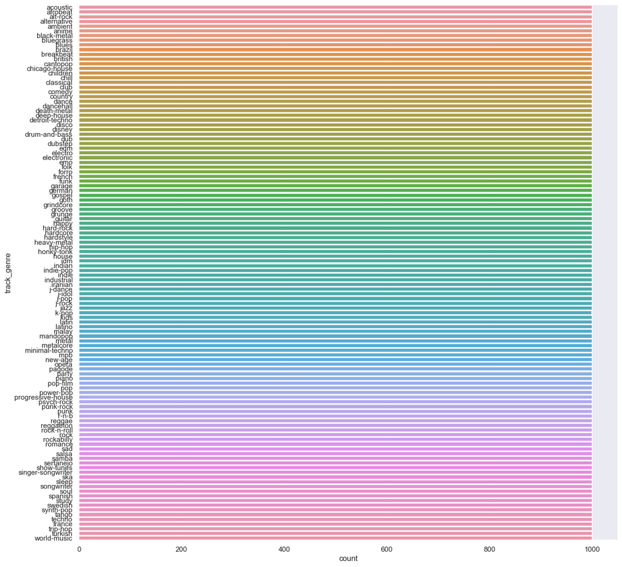

```python
sns.set(rc = {'figure.figsize':(15,15)})
sns.countplot(y="track_genre", data=songs)
```

From this we can see that we were right. Our dataset consists of 1000 songs from 114 different genres. Out of curiousity lets see what happens when we make a count plot of our dataset with duplicates dropped by keeping the first instance.

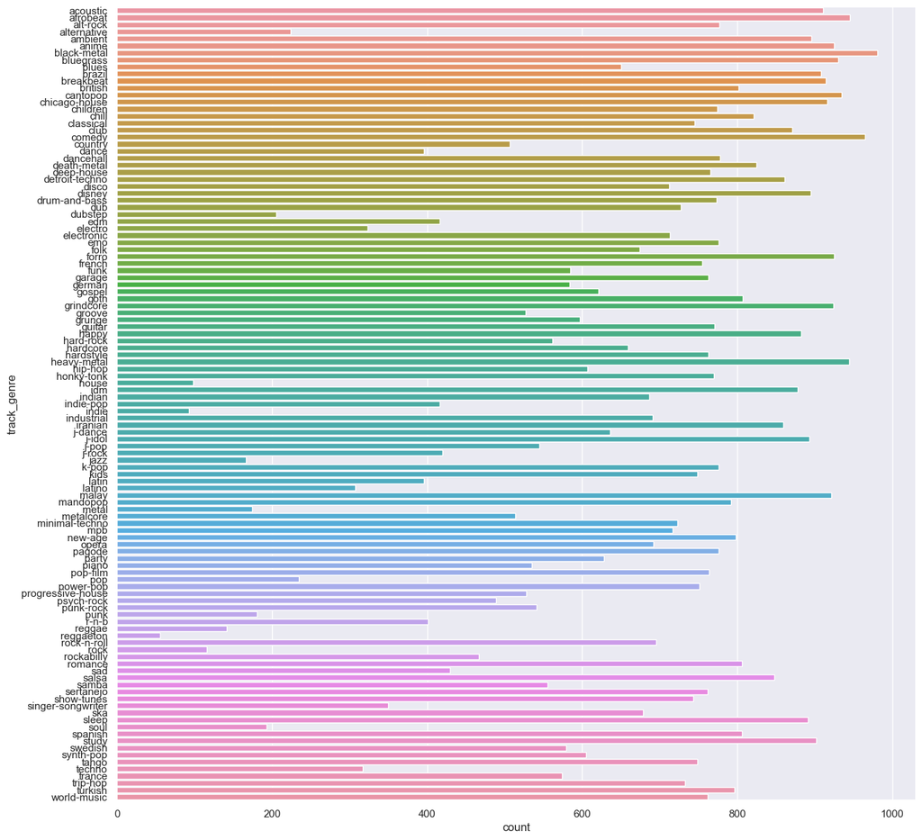

```python
songs_no_dup_basic = songs.drop_duplicates(subset=['track_name'],keep='first')
sns.set(rc = {'figure.figsize':(15,15)})
sns.countplot(y="track_genre", data=songs_no_dup_basic)
```

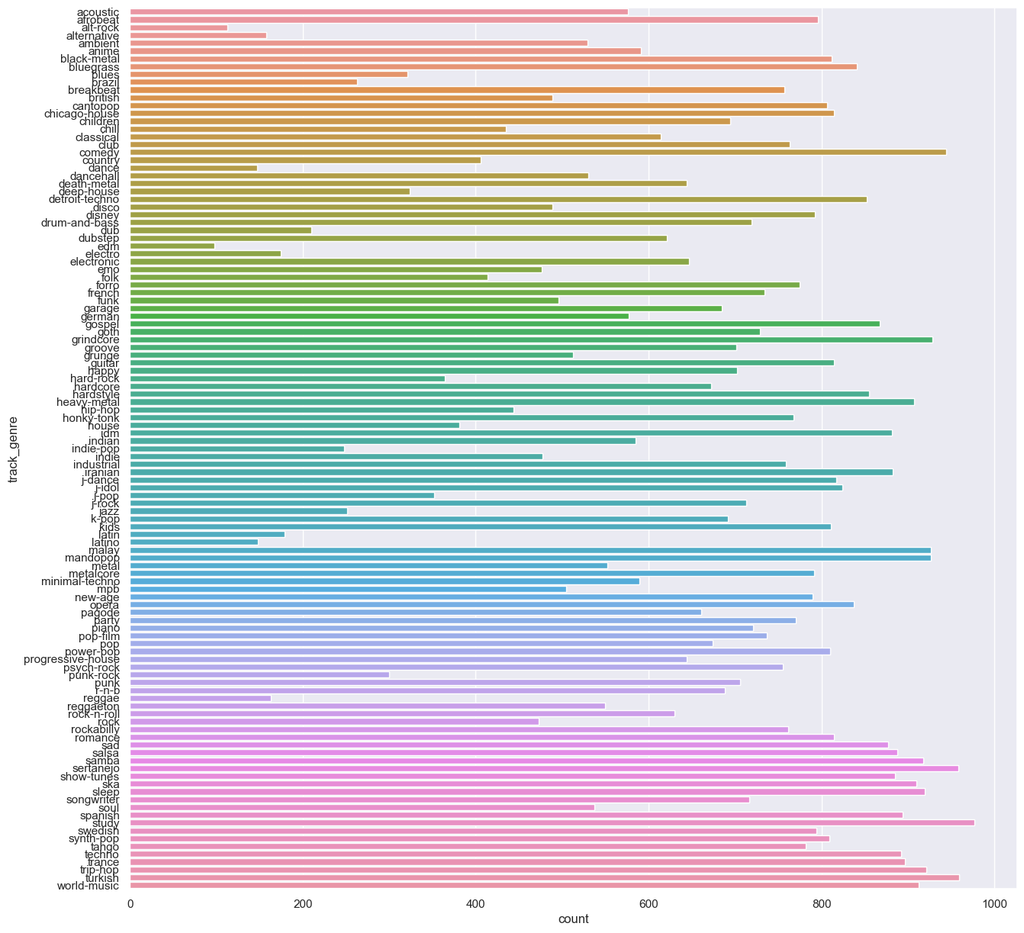

```python
songs_no_dup_basic = songs.drop_duplicates(subset=['track_name'],keep='last')
sns.set(rc = {'figure.figsize':(15,15)})
sns.countplot(y="track_genre", data=songs_no_dup_basic)
```

As expected you can see how the trend flips when we keep the last duplicate instead. Changing the orders of the genres and changing how we remove duplicates could possibly make this plot behave different but for now lets move on to more interesting data.

## Finding Correlations from Song Data

Before I get into trying to predict the genre of songs I first want to explore the relationships between a song's, what I refer to as, "physical properties". It is often useful to look at the reltionships of the data you will be using before jumping into any complicated experiments, as preparing the data properly and also fully understanding the data, will help signifcanlty down the line. So first lets double check to see all our dataframe features. For looking at the correlation of song properties I am going to use my naively duplicate-removed dataset since each duplicated song has the same properties just a different genre.

```python
songs_no_dup_basic.columns
```

```
Index(['Unnamed: 0', 'track_id', 'artists', 'album_name', 'track_name',
       'popularity', 'duration_ms', 'explicit', 'danceability', 'energy',
       'key', 'loudness', 'mode', 'speechiness', 'acousticness',
       'instrumentalness', 'liveness', 'valence', 'tempo', 'time_signature',
       'track_genre'],
      dtype='object')
```

I am interested in only the songs properties not the artist or album for now. So lets use bracket indexing once again to pull a subset dataframe from our orignal songs dataframe (with no duplicates).

```python
phy_song_attrs = songs_no_dup_basic[['danceability','energy','key','loudness','mode','speechiness','acousticness','instrumentalness','liveness','valence','tempo','time_signature']]
phy_song_attrs
```

|  | danceability | energy | key | loudness | mode | speechiness | acousticness | instrumentalness | liveness | valence | tempo | time_signature |
| --- | --- | --- | --- | --- | --- | --- | --- | --- | --- | --- | --- | --- |
| 2 | 0.438 | 0.359 | 0 | -9.734 | 1 | 0.0557 | 0.210 | 0.000000 | 0.1170 | 0.1200 | 76.332 | 4 |
| 14 | 0.755 | 0.780 | 2 | -6.084 | 1 | 0.0327 | 0.124 | 0.000028 | 0.1210 | 0.3870 | 120.004 | 4 |
| 32 | 0.593 | 0.455 | 6 | -8.192 | 1 | 0.0388 | 0.366 | 0.000000 | 0.0914 | 0.5640 | 202.019 | 4 |
| 40 | 0.474 | 0.519 | 7 | -5.291 | 1 | 0.0253 | 0.281 | 0.000000 | 0.1070 | 0.3260 | 151.832 | 4 |
| 54 | 0.576 | 0.331 | 6 | -9.389 | 0 | 0.0306 | 0.894 | 0.000034 | 0.1290 | 0.4070 | 149.020 | 4 |
| ... | ... | ... | ... | ... | ... | ... | ... | ... | ... | ... | ... | ... |
| 113995 | 0.172 | 0.235 | 5 | -16.393 | 1 | 0.0422 | 0.640 | 0.928000 | 0.0863 | 0.0339 | 125.995 | 5 |
| 113996 | 0.174 | 0.117 | 0 | -18.318 | 0 | 0.0401 | 0.994 | 0.976000 | 0.1050 | 0.0350 | 85.239 | 4 |
| 113997 | 0.629 | 0.329 | 0 | -10.895 | 0 | 0.0420 | 0.867 | 0.000000 | 0.0839 | 0.7430 | 132.378 | 4 |
| 113998 | 0.587 | 0.506 | 7 | -10.889 | 1 | 0.0297 | 0.381 | 0.000000 | 0.2700 | 0.4130 | 135.960 | 4 |
| 113999 | 0.526 | 0.487 | 1 | -10.204 | 0 | 0.0725 | 0.681 | 0.000000 | 0.0893 | 0.7080 | 79.198 | 4 |

73608 rows × 12 columns

Now we have a dataframe just containing entries with song properties. No song name, track, or album, just the properties. Now lets create something called a correlation matrix using pandas [corr()](https://pandas.pydata.org/pandas-docs/stable/reference/api/pandas.DataFrame.corr.html) function. The correlation matrix is exactly what it sounds like. It measures the correlation between two singlular features. A value of 1 or -1 means the two features are respectivly directly correlated or inversely correlated. While a score near zero means there is little correlation between the features.

```python
#get correlation matrix to see relationships betwen these physical properties
phy_song_attrs.corr()
```

|  | danceability | energy | key | loudness | mode | speechiness | acousticness | instrumentalness | liveness | valence | tempo | time_signature |
| --- | --- | --- | --- | --- | --- | --- | --- | --- | --- | --- | --- | --- |
| danceability | 1.000000 | 0.136334 | 0.033094 | 0.269681 | -0.058505 | 0.110161 | -0.168369 | -0.194656 | -0.134638 | 0.495070 | -0.012745 | 0.206724 |
| energy | 0.136334 | 1.000000 | 0.043021 | 0.759872 | -0.065261 | 0.139068 | -0.726780 | -0.186547 | 0.190145 | 0.255560 | 0.260178 | 0.179930 |
| key | 0.033094 | 0.043021 | 1.000000 | 0.034452 | -0.144485 | 0.011938 | -0.041431 | -0.003601 | -0.003911 | 0.026012 | 0.005615 | 0.016382 |
| loudness | 0.269681 | 0.759872 | 0.034452 | 1.000000 | -0.033075 | 0.052991 | -0.578358 | -0.433763 | 0.078728 | 0.294529 | 0.234430 | 0.193521 |
| mode | -0.058505 | -0.065261 | -0.144485 | -0.033075 | 1.000000 | -0.035196 | 0.078932 | -0.052109 | 0.019425 | 0.023198 | 0.000893 | -0.023011 |
| speechiness | 0.110161 | 0.139068 | 0.011938 | 0.052991 | -0.035196 | 1.000000 | 0.016296 | -0.108797 | 0.231131 | 0.033425 | -0.006065 | -0.013270 |
| acousticness | -0.168369 | -0.726780 | -0.041431 | -0.578358 | 0.078932 | 0.016296 | 1.000000 | 0.089930 | -0.012358 | -0.100537 | -0.222325 | -0.171911 |
| instrumentalness | -0.194656 | -0.186547 | -0.003601 | -0.433763 | -0.052109 | -0.108797 | 0.089930 | 1.000000 | -0.100749 | -0.338082 | -0.061295 | -0.082282 |
| liveness | -0.134638 | 0.190145 | -0.003911 | 0.078728 | 0.019425 | 0.231131 | -0.012358 | -0.100749 | 1.000000 | 0.011342 | -0.010588 | -0.031998 |
| valence | 0.495070 | 0.255560 | 0.026012 | 0.294529 | 0.023198 | 0.033425 | -0.100537 | -0.338082 | 0.011342 | 1.000000 | 0.095828 | 0.133904 |
| tempo | -0.012745 | 0.260178 | 0.005615 | 0.234430 | 0.000893 | -0.006065 | -0.222325 | -0.061295 | -0.010588 | 0.095828 | 1.000000 | 0.091377 |
| time_signature | 0.206724 | 0.179930 | 0.016382 | 0.193521 | -0.023011 | -0.013270 | -0.171911 | -0.082282 | -0.031998 | 0.133904 | 0.091377 | 1.000000 |

In order to visualize this better we can plot a [heatmap](https://seaborn.pydata.org/generated/seaborn.heatmap.html) of the correlation matrix using seaborn. A heatmap shows the same information as the correlation matrix however it color codes it in order to make it easier to pick out higher correlated features amongst lower corrletaed features.

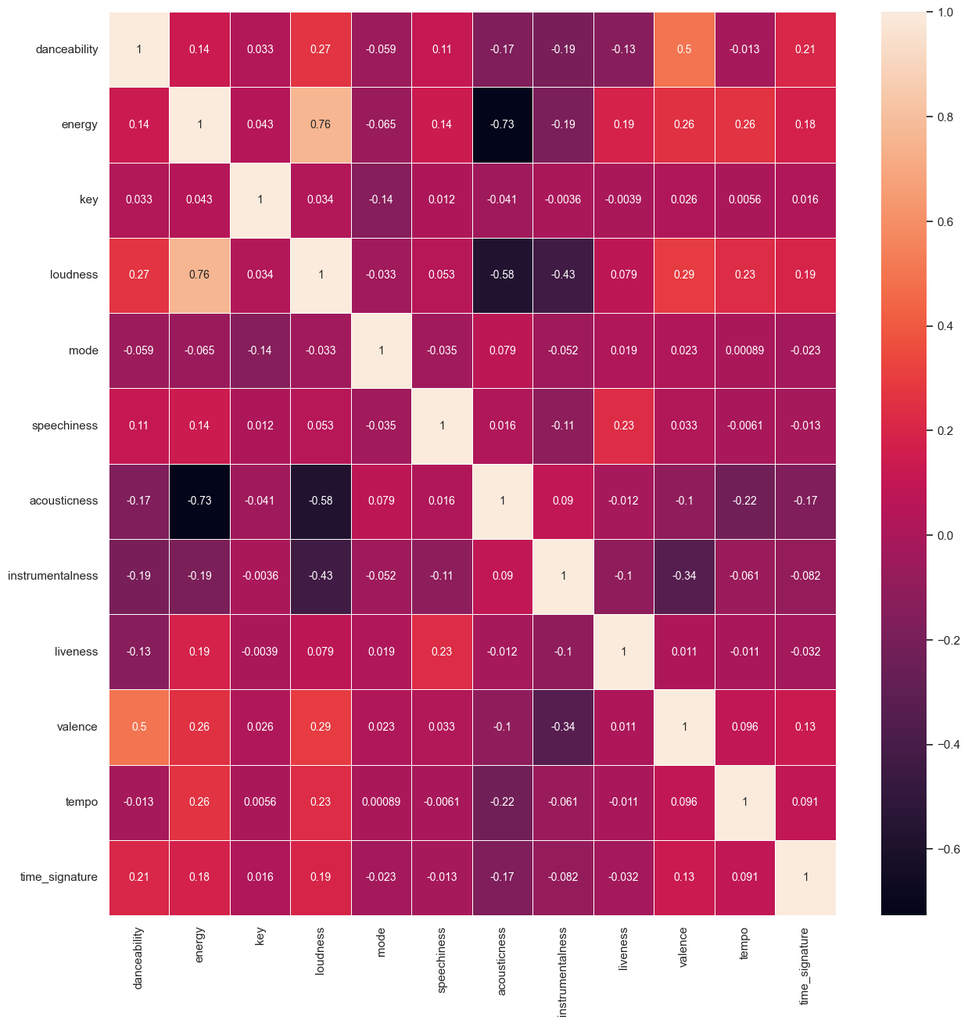

```python
sns.heatmap(phy_song_attrs.corr(),annot=True,linewidth = .5,annot_kws={"fontsize":10})
```

## Unsupervised Learning vs Supervised Learning

One of my main goals in this tutorial is to explore the [difference between supervised and unsupervised learning models](https://www.ibm.com/cloud/blog/supervised-vs-unsupervised-learning). When it comes down to it they are fundamentally different. Supervised learning is used for labeled datasets while unsupervised learing aims to find patterns and groups from unlabeled data. In general if you have labels you want to use supervised learning because the model will learn and adjust itself based on the labels it knows. In the context of my problem, predicting genre, an unsupervised learning approach would be to pretend I dont have genre labels given to me and see how well we can cluster songs based on their properties. Although this is less likely to work I find it an interesting experiment to do just to see what we come up with. On the other hand, supervised learning in our context would feed the physical properties of our songs and their corrospnding labels (genre) so that the model can learn over time.

### Unsupervised Learning: KMeans

[KMeans](https://scikit-learn.org/stable/modules/generated/sklearn.cluster.KMeans.html) is an unsupervised learning algorithm from sci kit learn that I will be using for this tutorial. The KMeans algorithm tries to group similar items into K clusters based on the similarity of their features. It is easy to picture in two or three dimensions as the algoirthm selects clusters of data points near each other. Although we cannot picture it multi-dimensionally, the computer can still calculate it. There are several important properties of the KMeans algorithm that you should know as well. "n_clusters" or K which represents the number of clusters we want to find, "n_init" which is the number of times the algorithm runs with different starting cluster locations, "max_iter" which defines the maxiumum amount of iterations allowed to converge and select our clusters, and finally "random_state" which we just set to an arbitrary value in order to reproduce our results.

So lets start by creating our first KMeans model. Lets assume to start that we want to cluster our data into ten groups and see what it does. After assigning parameter values we need to fit the model to the data we want it to cluster. Our data we are using is the dataframe containing rows of song attributes with no name, artist, etc. We can access the labels attributes of the model simply as you see below. Labels returns a list the legnth of the dataframe and containing numbers 0 to (n_clusters-1) which represent the labels the model has assigned to each row of attributes.

```python
initial_model = KMeans(
    init='random',
    n_clusters=10,
    n_init=10,
    max_iter=300,
    random_state=42
    )
initial_model.fit(phy_song_attrs)
labels = initial_model.labels_
print(labels)
```

```
[4 6 1 2 2 9 4 6 8 4 4 6 2 9 3 ... 0 9 6 0 6 3 2 3 3 0 6 4 0 0 4]
```

Using the same "songs_no_dup_basic" dataframe that phy_song_attrs was extracted from lets make a copy and add our list of labels as a new column. In order to visualize the result I use seaborn to plot a [count plot](https://seaborn.pydata.org/generated/seaborn.countplot.html) showing the distrobution of genres accross the labels of our KMeans model.

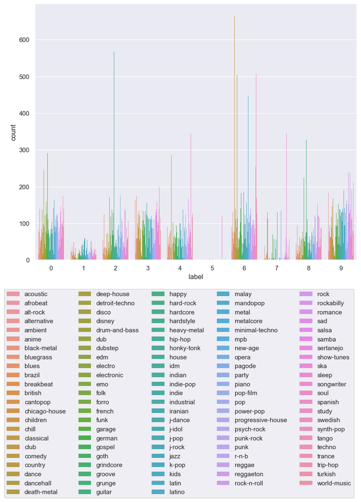

```python
songs_with_label = songs_no_dup_basic.copy()
songs_with_label['label']=labels
#count genre occurances
sns.set(rc = {'figure.figsize':(10,8)})
ax = sns.countplot(data=songs_with_label,x="label",hue="track_genre",linewidth=0)
plt.legend(loc=1,ncol=5,bbox_to_anchor=(1,-0.1))
```

This result is definitely not great in terms of fitting the songs to genres. However, before we move on we should always try to adjust the paramters of the model in order to accomadate your data better and get the most accurate result you can. So how do we do this for KMeans? The answer is something called the [elbow method](https://www.scikit-yb.org/en/latest/api/cluster/elbow.html). With the elbow method you plot the sums of the squared distances from each point to its assigned center, called distortions, for a range of different K (number of clusters) values. The point of inflection on the curve is the value of the best K value.

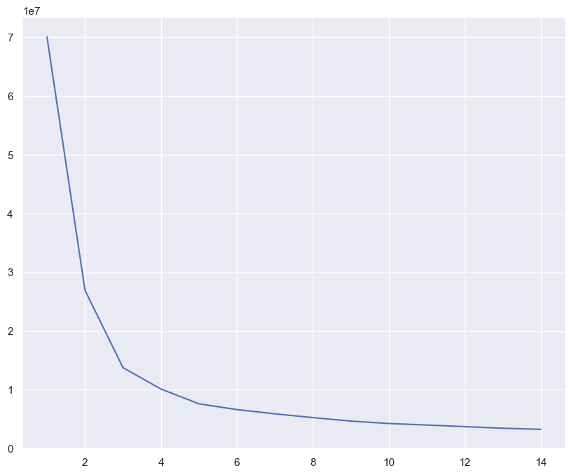

```python
#lets use the elbow method to estimate number of clusters
maxk = 15
sse_vals = []
for k in range(1,maxk):
    model = KMeans(
    init='random',
    n_clusters=k,
    n_init=10,
    max_iter=300,
    random_state=42
    )
    model.fit(phy_song_attrs)
    sse_vals.append(model.inertia_)

sns.lineplot(data=sse_vals, x=range(1,maxk), y=sse_vals)
```

This tells us that the optimal K value is 3, at least in terms of minimized distance to the center of each cluster. So lets try creating a model with the number of clusters equal to 3 and see what our plot looks like.

```python
k3_model = KMeans(
    init='random',
    n_clusters=3,
    n_init=10,
    max_iter=300,
    random_state=42
    )
k3_model.fit(phy_song_attrs)
labels = k3_model.labels_
print(labels)
```

```
[1 0 2 2 2 1 1 0 2 1 1 0 2 1 0 ... 0 1 0 0 0 0 0 0 1 0 0 1 0 0 1]
```

Lets plot again to visualize our results.

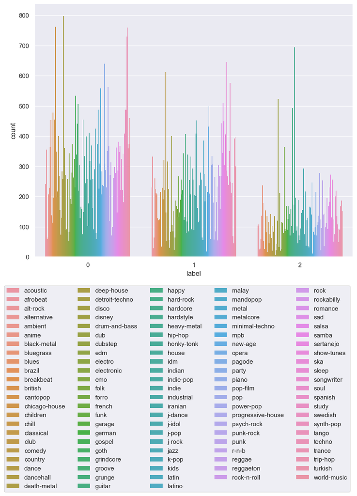

```python
songs_with_label = songs_no_dup_basic.copy()
songs_with_label['label']=labels
#count genre occurances
ax = sns.countplot(data=songs_with_label,x="label",hue="track_genre",linewidth=0)
plt.legend(loc=1,ncol=5,bbox_to_anchor=(1,-0.1))
plt.show()
```

From the fact that this is the most optimal K value according to distance and we see that the genres are rather evenly spread in each group with no significant trends, it is safe to assume KMeans can not group the songs into genres. Of course many of you, including myself, may have suspected this result. Although it doesnt do a good job of grouping the songs into genres, its information is still just as important as if it did. We now know that the physical song properties are not so directly correlated to the genre or else we would have been able to separate better. I dont know about you but while I was exploring the data, a small part of me wondered, what if I tried 114 genres? So for the sake of showing how poorly it performs for those of you curious here you go.

```python
k114_model = KMeans(
    init='random',
    n_clusters=114,
    n_init=10,
    max_iter=300,
    random_state=42
    )
k114_model.fit(phy_song_attrs)
labels = k114_model.labels_
print(labels)
```

```
[ 15  85  74  77 113  96 111  85  27 111 111  92  77  43  32 ...  44  56
   8  16  11  70  25  45 107  11  11  14  41  80 111]
```

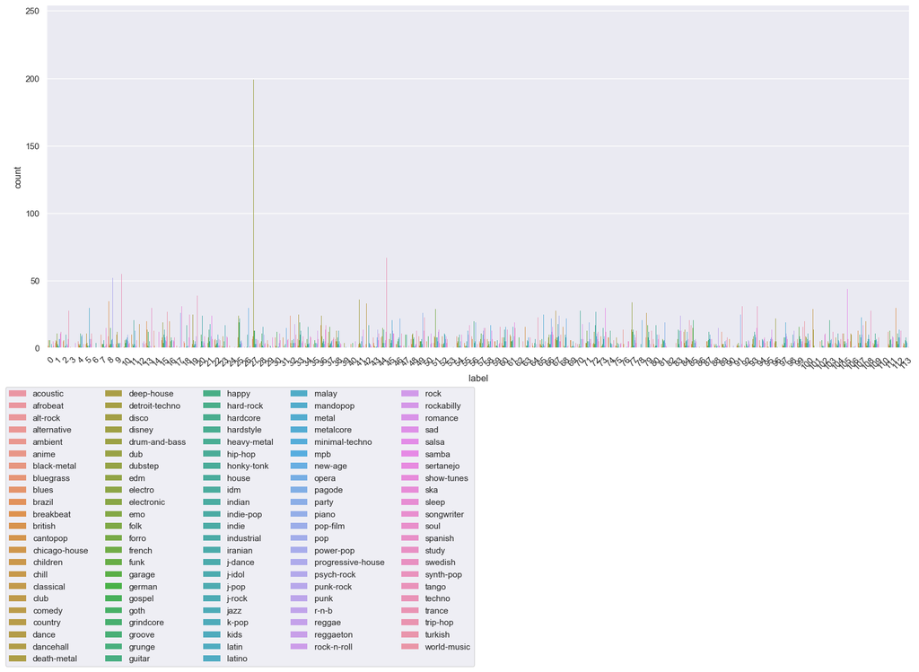

```python
#now how can we visualize how well our kmeans did?
songs_with_label = songs_no_dup_basic.copy()
songs_with_label['label']=labels
#count genre occurances
sns.set(rc = {'figure.figsize':(20,8)})
ax = sns.countplot(data=songs_with_label,x="label",hue="track_genre",linewidth=0)
plt.legend(loc=1,ncol=5,bbox_to_anchor=(.5,-0.1))
plt.xticks(rotation=45)
plt.show()
```

Well, besides a few outliars, the data still does not group which is expected. So with the information we have learned lets move on and see if using supervised learning can help.

### Supervised Learning: K Nearest Neighbors Classification

Now that we have explored the unsupervised learning algorithm, KMeans, lets talk about K Nearest Neighbors (KNN). A lot of people when they hear KMeans and KNN assume they are the same thing which is not true. KMeans as discussed before clusters unlabeled data according to its attributes. KNN on the other hand, because we use labels, uses the attributes of a song to classify it based on its K closest, already labeled, points. The tutorial [here](https://www.datacamp.com/tutorial/k-nearest-neighbor-classification-scikit-learn) does a great job walking through and explaining KNN if you are interested. For now I will move onto implementing it.

Lets set up our data for the KNN classifier. Our independant variable, or X, will be the dataframe containing the numerical song attributes we are using to try to predict genre. Of course, our y or dependant variable would then be the corrosponding list of genres for each of these songs. You may notice that I am using the full dataset of songs here, not the ones with duplicates removed because now that we are using the genre labeling, throwing out data could mislead us.

Lets start by standardizing our data using sklearns [StandardScalar()](https://scikit-learn.org/stable/modules/generated/sklearn.preprocessing.StandardScaler.html). This function allows us to standardize each column of the X dataset so that no feature exerts more numerical influence than another, that is of course unless we decided we wanted this to be the case. Next we can use sklearns [train_test_split](https://scikit-learn.org/stable/modules/generated/sklearn.model_selection.train_test_split.html) function to automatically divide our data into a test set and training set.

```python
X = songs[['danceability','energy','key','loudness','mode','speechiness','acousticness','instrumentalness','liveness','valence','tempo','time_signature']]
y = songs[['track_genre']]

#scaled the data
scaler = StandardScaler()
scaler.fit(X)
scaled_song_attrs = scaler.transform(X)
X_scaled = pd.DataFrame(scaled_song_attrs,columns=X.columns[:])

X_train, X_test, y_train, y_test = train_test_split(X_scaled, y, test_size=0.3, random_state=30, shuffle=True)
```

Lets use sklearns [KNeighborsClassifier](https://scikit-learn.org/stable/modules/generated/sklearn.neighbors.KNeighborsClassifier.html) with some default paramter values and see how we do. Unlike in KMeans where we just fit our data to the dataset we also now need to actually use the model to predict new data from our test set and analyze how accurate we were.

```python
knn = KNeighborsClassifier(n_neighbors=5,p=2,metric='euclidean')
knn.fit(X_train, y_train.values.ravel())

prediction = knn.predict(X_test)
prediction

print(classification_report(y_test.values.ravel(), prediction))
```

```
                   precision    recall  f1-score   support

         acoustic       0.05      0.15      0.07       274
         afrobeat       0.07      0.19      0.10       294
         alt-rock       0.03      0.10      0.05       319
      alternative       0.07      0.14      0.09       289
          ambient       0.11      0.24      0.15       297
            anime       0.04      0.10      0.05       299
      black-metal       0.17      0.31      0.22       330
        bluegrass       0.10      0.23      0.14       298
            blues       0.07      0.15      0.09       308
           brazil       0.02      0.06      0.04       311
        breakbeat       0.11      0.20      0.14       328
          british       0.05      0.08      0.06       342
         cantopop       0.07      0.17      0.10       274
    chicago-house       0.19      0.36      0.25       280
         children       0.14      0.21      0.17       292
            chill       0.06      0.09      0.07       321
        classical       0.24      0.31      0.27       278
             club       0.10      0.12      0.11       334
           comedy       0.74      0.80      0.77       313
          country       0.22      0.43      0.29       300
            dance       0.18      0.33      0.23       309
        dancehall       0.11      0.19      0.14       306
      death-metal       0.10      0.17      0.13       309
       deep-house       0.08      0.14      0.10       293
   detroit-techno       0.21      0.26      0.23       265
            disco       0.09      0.12      0.10       330
           disney       0.15      0.18      0.16       267
    drum-and-bass       0.33      0.41      0.36       334
              dub       0.05      0.08      0.06       303
          dubstep       0.07      0.06      0.07       307
              edm       0.05      0.09      0.07       289
          electro       0.16      0.25      0.19       275
       electronic       0.04      0.04      0.04       313
              emo       0.07      0.09      0.08       299
             folk       0.08      0.12      0.10       313
            forro       0.24      0.27      0.25       327
           french       0.08      0.07      0.07       296
             funk       0.14      0.18      0.16       273
```

[output cut: 65 more lines]

```
             soul       0.34      0.18      0.24       298
          spanish       0.13      0.04      0.06       290
            study       0.51      0.42      0.46       320
          swedish       0.20      0.09      0.12       310
        synth-pop       0.21      0.08      0.12       312
            tango       0.59      0.32      0.42       306
           techno       0.11      0.06      0.07       303
           trance       0.26      0.20      0.23       300
         trip-hop       0.12      0.03      0.05       301
          turkish       0.07      0.02      0.03       288
      world-music       0.30      0.17      0.21       299

         accuracy                           0.15     34200
        macro avg       0.17      0.15      0.15     34200
     weighted avg       0.17      0.15      0.15     34200
```

Sklearns [classification report](https://scikit-learn.org/stable/modules/generated/sklearn.metrics.classification_report.html) is very useful as it shows the precision, recall, f1 score, and support of each catagory. Although overall it did not perform well, there were instances like comedy for example that had a recall of 0.8. It is definitely interesting seeing this performance which led me to wonder what would happen if I were to cluster the data using KMeans and then use KNN on each cluster to see if there is actually any difference in the clusters we found. This is not as standard of a process but just something I wanted to try out of curiosity so lets do it! Lets use our optimal KMeans of 3 clusters and split the data by label.

However, first we need to rerun our KMeans because when we were doing initial clustering we removed duplicates but now that we will be running KNN, keep these duplicates removed would be innacurate.

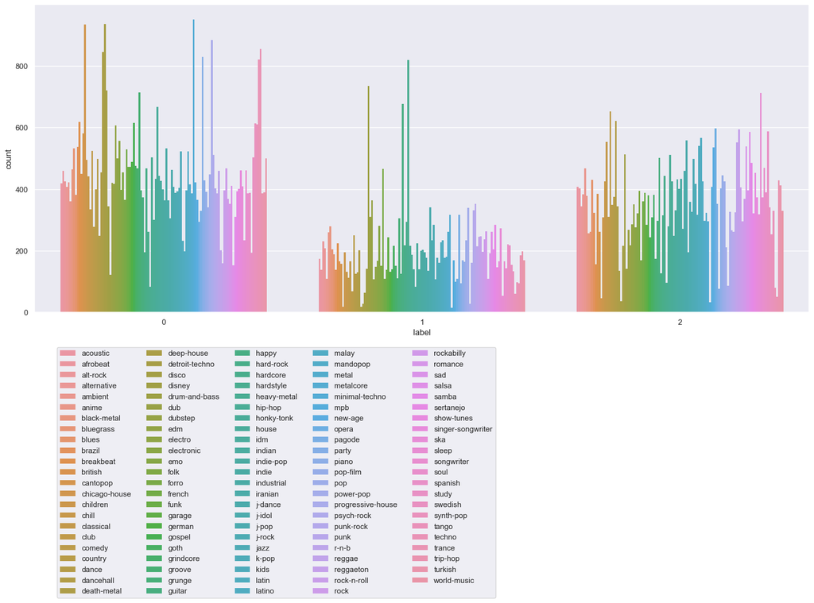

```python
phy_song_attrs = songs[['danceability','energy','key','loudness','mode','speechiness','acousticness','instrumentalness','liveness','valence','tempo','time_signature']]
k3_model = KMeans(
    init='random',
    n_clusters=3,
    n_init=10,
    max_iter=300,
    random_state=42
    )
k3_model.fit(phy_song_attrs)
labels = k3_model.labels_
songs_with_label = songs.copy()
songs_with_label['label']=labels
#count genre occurances
ax = sns.countplot(data=songs_with_label,x="label",hue="track_genre",linewidth=0)
plt.legend(loc=1,ncol=5,bbox_to_anchor=(.6,-0.1))
plt.show()
```

```python
songs_with_label = songs.copy()
songs_with_label['label']=k3_model.labels_

group_0 = songs_with_label.loc[songs_with_label['label'] == 0]
group_1 = songs_with_label.loc[songs_with_label['label'] == 1]
group_2 = songs_with_label.loc[songs_with_label['label'] == 2]
group_0
```

|  | Unnamed: 0 | track_id | artists | album_name | track_name | popularity | duration_ms | explicit | danceability | energy | ... | mode | speechiness | acousticness | instrumentalness | liveness | valence | tempo | time_signature | track_genre | label |
| --- | --- | --- | --- | --- | --- | --- | --- | --- | --- | --- | --- | --- | --- | --- | --- | --- | --- | --- | --- | --- | --- |
| 4 | 4 | 5vjLSffimiIP26QG5WcN2K | Chord Overstreet | Hold On | Hold On | 82 | 198853 | False | 0.618 | 0.443 | ... | 1 | 0.0526 | 0.4690 | 0.000000 | 0.0829 | 0.1670 | 119.949 | 4 | acoustic | 0 |
| 6 | 6 | 6Vc5wAMmXdKIAM7WUoEb7N | A Great Big World;Christina Aguilera | Is There Anybody Out There? | Say Something | 74 | 229400 | False | 0.407 | 0.147 | ... | 1 | 0.0355 | 0.8570 | 0.000003 | 0.0913 | 0.0765 | 141.284 | 3 | acoustic | 0 |
| 8 | 8 | 0IktbUcnAGrvD03AWnz3Q8 | Jason Mraz;Colbie Caillat | We Sing. We Dance. We Steal Things. | Lucky | 74 | 189613 | False | 0.625 | 0.414 | ... | 1 | 0.0369 | 0.2940 | 0.000000 | 0.1510 | 0.6690 | 130.088 | 4 | acoustic | 0 |
| 11 | 11 | 5ivF4eQBqJiVL5IAE9jRyl | Jason Mraz | Love Is a Four Letter Word | I Won't Give Up | 69 | 240165 | False | 0.483 | 0.303 | ... | 1 | 0.0429 | 0.6940 | 0.000000 | 0.1150 | 0.1390 | 133.406 | 3 | acoustic | 0 |
| 12 | 12 | 4ptDJbJl35d7gQfeNteBwp | Dan Berk | Solo | Solo | 52 | 198712 | False | 0.489 | 0.314 | ... | 0 | 0.0331 | 0.7490 | 0.000000 | 0.1130 | 0.6070 | 124.234 | 4 | acoustic | 0 |
| ... | ... | ... | ... | ... | ... | ... | ... | ... | ... | ... | ... | ... | ... | ... | ... | ... | ... | ... | ... | ... | ... |
| 113992 | 113992 | 3FjOBB4EyIXHYUtSgrIdY9 | Jesus Culture | Revelation Songs | Your Love Never Fails | 38 | 312566 | False | 0.475 | 0.860 | ... | 1 | 0.0421 | 0.0065 | 0.000002 | 0.2460 | 0.4270 | 113.949 | 4 | world-music | 0 |
| 113994 | 113994 | 4WbOUe6T0sozC7z5ZJgiAA | Lucas Cervetti | Frecuencias Álmicas en 432hz | Frecuencia Álmica, Pt. 4 | 22 | 305454 | False | 0.331 | 0.171 | ... | 1 | 0.0350 | 0.9200 | 0.022900 | 0.0679 | 0.3270 | 132.147 | 3 | world-music | 0 |
| 113995 | 113995 | 2C3TZjDRiAzdyViavDJ217 | Rainy Lullaby | #mindfulness - Soft Rain for Mindful Meditatio... | Sleep My Little Boy | 21 | 384999 | False | 0.172 | 0.235 | ... | 1 | 0.0422 | 0.6400 | 0.928000 | 0.0863 | 0.0339 | 125.995 | 5 | world-music | 0 |
| 113997 | 113997 | 6x8ZfSoqDjuNa5SVP5QjvX | Cesária Evora | Best Of | Miss Perfumado | 22 | 271466 | False | 0.629 | 0.329 | ... | 0 | 0.0420 | 0.8670 | 0.000000 | 0.0839 | 0.7430 | 132.378 | 4 | world-music | 0 |
| 113998 | 113998 | 2e6sXL2bYv4bSz6VTdnfLs | Michael W. Smith | Change Your World | Friends | 41 | 283893 | False | 0.587 | 0.506 | ... | 1 | 0.0297 | 0.3810 | 0.000000 | 0.2700 | 0.4130 | 135.960 | 4 | world-music | 0 |

51116 rows × 22 columns

Lets copy what we just did with KNN and now apply it to each group.

#### Group 0

```python
#now lets try to determine the genre using a k-nn classification
X = group_0[['danceability','energy','key','loudness','mode','speechiness','acousticness','instrumentalness','liveness','valence','tempo','time_signature']]
y = group_0[['track_genre']]

#scaled the data
scaler = StandardScaler()
scaler.fit(X)
scaled_song_attrs = scaler.transform(X)
X_scaled = pd.DataFrame(scaled_song_attrs,columns=X.columns[:])

X_train, X_test, y_train, y_test = train_test_split(X_scaled, y, test_size=0.3, random_state=30, shuffle=True)
knn = KNeighborsClassifier(n_neighbors=7,p=2,metric='euclidean')
knn.fit(X_train, y_train.values.ravel())

prediction = knn.predict(X_test)
prediction

print(classification_report(y_test.values.ravel(), prediction))
```

```
                   precision    recall  f1-score   support

         acoustic       0.07      0.22      0.11       130
         afrobeat       0.05      0.13      0.08       132
         alt-rock       0.03      0.08      0.04       130
      alternative       0.08      0.16      0.11       118
          ambient       0.09      0.18      0.12       122
            anime       0.04      0.09      0.05       102
      black-metal       0.16      0.29      0.21       137
        bluegrass       0.14      0.33      0.20       146
            blues       0.05      0.12      0.07       105
           brazil       0.03      0.06      0.04       159
        breakbeat       0.14      0.23      0.17       192
          british       0.05      0.11      0.07       106
         cantopop       0.09      0.19      0.12       163
    chicago-house       0.23      0.42      0.30       276
         children       0.22      0.20      0.21       161
            chill       0.05      0.04      0.04       146
        classical       0.28      0.38      0.32       102
             club       0.10      0.10      0.10       165
           comedy       0.66      0.70      0.68        84
          country       0.18      0.34      0.24       122
            dance       0.15      0.33      0.20       136
        dancehall       0.15      0.18      0.16        73
      death-metal       0.16      0.19      0.18       140
       deep-house       0.09      0.17      0.12       245
   detroit-techno       0.24      0.27      0.26       270
            disco       0.08      0.11      0.09       197
           disney       0.08      0.07      0.07       101
    drum-and-bass       0.09      0.07      0.08        42
              dub       0.04      0.05      0.05       132
          dubstep       0.09      0.06      0.07       125
              edm       0.12      0.16      0.14       203
          electro       0.14      0.15      0.14       158
       electronic       0.04      0.02      0.03       178
              emo       0.04      0.04      0.04       117
             folk       0.07      0.08      0.08       119
            forro       0.21      0.23      0.22       113
           french       0.07      0.04      0.05       192
             funk       0.11      0.12      0.12       148
```

[output cut: 65 more lines]

```
             soul       0.24      0.15      0.18       117
          spanish       0.00      0.00      0.00       130
            study       0.32      0.20      0.25        59
          swedish       0.05      0.03      0.04       152
        synth-pop       0.23      0.12      0.16       202
            tango       0.50      0.43      0.46       189
           techno       0.15      0.10      0.12       255
           trance       0.29      0.27      0.27       249
         trip-hop       0.04      0.01      0.01       122
          turkish       0.08      0.03      0.05       115
      world-music       0.23      0.21      0.22       144

         accuracy                           0.15     15335
        macro avg       0.15      0.14      0.13     15335
     weighted avg       0.15      0.15      0.14     15335
```

#### Group 1

```python
#now lets try to determine the genre using a k-nn classification
X = group_1[['danceability','energy','key','loudness','mode','speechiness','acousticness','instrumentalness','liveness','valence','tempo','time_signature']]
y = group_1[['track_genre']]

#scaled the data
scaler = StandardScaler()
scaler.fit(X)
scaled_song_attrs = scaler.transform(X)
X_scaled = pd.DataFrame(scaled_song_attrs,columns=X.columns[:])

X_train, X_test, y_train, y_test = train_test_split(X_scaled, y, test_size=0.3, random_state=30, shuffle=True)
knn = KNeighborsClassifier(n_neighbors=7,p=2,metric='euclidean')
knn.fit(X_train, y_train.values.ravel())

prediction = knn.predict(X_test)
prediction

print(classification_report(y_test.values.ravel(), prediction))
```

```
                   precision    recall  f1-score   support

         acoustic       0.03      0.12      0.05        49
         afrobeat       0.06      0.17      0.09        41
         alt-rock       0.04      0.16      0.07        63
      alternative       0.06      0.13      0.08        60
          ambient       0.14      0.27      0.19        33
            anime       0.05      0.15      0.07        67
      black-metal       0.26      0.44      0.33        91
        bluegrass       0.09      0.20      0.12        64
            blues       0.11      0.27      0.15        51
           brazil       0.03      0.07      0.05        43
        breakbeat       0.12      0.25      0.17        60
          british       0.03      0.03      0.03        58
         cantopop       0.02      0.05      0.03        38
    chicago-house       0.00      0.00      0.00         3
         children       0.11      0.16      0.13        50
            chill       0.02      0.02      0.02        42
        classical       0.20      0.40      0.27        25
             club       0.03      0.02      0.02        65
           comedy       0.36      0.48      0.41        25
          country       0.21      0.38      0.27        80
            dance       0.18      0.32      0.23        37
        dancehall       0.10      0.12      0.11        40
      death-metal       0.07      0.08      0.07        51
       deep-house       0.00      0.00      0.00         6
   detroit-techno       0.00      0.00      0.00         9
            disco       0.14      0.25      0.18        12
           disney       0.24      0.20      0.22        54
    drum-and-bass       0.36      0.59      0.45       218
              dub       0.04      0.06      0.05        98
          dubstep       0.08      0.08      0.08       111
              edm       0.04      0.06      0.05        31
          electro       0.23      0.26      0.24        42
       electronic       0.05      0.02      0.03        57
              emo       0.01      0.01      0.01        90
             folk       0.10      0.13      0.12        46
            forro       0.33      0.48      0.39       135
           french       0.00      0.00      0.00        33
             funk       0.05      0.02      0.03        43
```

[output cut: 65 more lines]

```
             soul       0.41      0.22      0.28        51
          spanish       0.09      0.05      0.07        57
            study       0.53      0.57      0.55        84
          swedish       0.17      0.09      0.11        47
        synth-pop       0.12      0.08      0.10        39
            tango       0.20      0.07      0.10        15
           techno       0.00      0.00      0.00        38
           trance       0.33      0.04      0.06        28
         trip-hop       0.06      0.02      0.03        61
          turkish       0.09      0.05      0.06        60
      world-music       0.26      0.23      0.24        48

         accuracy                           0.16      6806
        macro avg       0.15      0.14      0.13      6806
     weighted avg       0.16      0.16      0.15      6806
```

#### Group 2

```python
#now lets try to determine the genre using a k-nn classification
X = group_2[['danceability','energy','key','loudness','mode','speechiness','acousticness','instrumentalness','liveness','valence','tempo','time_signature']]
y = group_2[['track_genre']]

#scaled the data
scaler = StandardScaler()
scaler.fit(X)
scaled_song_attrs = scaler.transform(X)
X_scaled = pd.DataFrame(scaled_song_attrs,columns=X.columns[:])

X_train, X_test, y_train, y_test = train_test_split(X_scaled, y, test_size=0.3, random_state=30, shuffle=True)
knn = KNeighborsClassifier(n_neighbors=7,p=2,metric='euclidean')
knn.fit(X_train, y_train.values.ravel())

prediction = knn.predict(X_test)
prediction

print(classification_report(y_test.values.ravel(), prediction))
```

```
                   precision    recall  f1-score   support

         acoustic       0.05      0.20      0.08       116
         afrobeat       0.08      0.23      0.12       112
         alt-rock       0.01      0.02      0.01       102
      alternative       0.10      0.19      0.13       127
          ambient       0.12      0.23      0.16       133
            anime       0.04      0.08      0.05       116
      black-metal       0.13      0.22      0.16        73
        bluegrass       0.05      0.11      0.07        80
            blues       0.07      0.14      0.09       126
           brazil       0.03      0.07      0.04        91
        breakbeat       0.08      0.14      0.11        49
          british       0.04      0.06      0.05       124
         cantopop       0.03      0.06      0.04        81
    chicago-house       0.00      0.00      0.00        14
         children       0.18      0.20      0.19        85
            chill       0.08      0.12      0.10       127
        classical       0.24      0.33      0.28       150
             club       0.14      0.19      0.16       102
           comedy       0.85      0.89      0.87       202
          country       0.22      0.38      0.28       120
            dance       0.16      0.36      0.22       112
        dancehall       0.15      0.20      0.17       199
      death-metal       0.13      0.19      0.16        99
       deep-house       0.03      0.04      0.04        45
   detroit-techno       0.00      0.00      0.00        11
            disco       0.12      0.22      0.16        60
           disney       0.20      0.21      0.20       146
    drum-and-bass       0.19      0.14      0.16        44
              dub       0.07      0.09      0.08        78
          dubstep       0.04      0.03      0.03        75
              edm       0.04      0.07      0.05        80
          electro       0.14      0.16      0.15       109
       electronic       0.03      0.01      0.02        79
              emo       0.04      0.03      0.04        86
             folk       0.05      0.05      0.05       122
            forro       0.10      0.05      0.07        58
           french       0.05      0.04      0.04       108
             funk       0.16      0.17      0.17       116
```

[output cut: 65 more lines]

```
             soul       0.25      0.21      0.23       145
          spanish       0.05      0.01      0.02       136
            study       0.48      0.59      0.53       186
          swedish       0.21      0.16      0.18        95
        synth-pop       0.05      0.02      0.03        81
            tango       0.25      0.10      0.14        90
           techno       0.00      0.00      0.00        29
           trance       0.00      0.00      0.00        15
         trip-hop       0.18      0.08      0.11       133
          turkish       0.06      0.03      0.04       111
      world-music       0.11      0.07      0.09        97

         accuracy                           0.16     12060
        macro avg       0.14      0.13      0.13     12060
     weighted avg       0.17      0.16      0.16     12060
```

Looking through the differences between the three groups there are definitely genres that behave better or worse in certain groups. Whether this information is significant or not would require furthur exploration but for the point of this tutorial I want to move onto using multi-label classifcation

### Supervised Learning: Multi-Label K Nearest Neighbors Classification

Up until this point we have been exploring relationships in our data but not using the correct method. In our KNN we are trying to guess a genre for a song that could actually have several genres. A normal KNN like that of which we used cant handle this properly. So I wanted to explore a type of machine learning algorithm that is admittedly new to me but a perfect fit for our data. Just as the name sounds [multi-label classification](http://scikit.ml/api/skmultilearn.adapt.mlknn.html)(mlKNN) allows the model not only to predict one genre but rather several. In order to do this we have some more preprocessing steps we need to take. Right now each song entry is labeled with one of 114 different genres but what I want to do is condense this by making a new column, in my dataset with no duplicates, that will store all the genres for each song. From there I will need to one hot encode all the genres so that each genre is its own column with a value of 0 or 1 for each unique song because this is the way mlKNN takes in the Y or dependant variables.

```python
print(pd.unique(songs['track_genre']))
```

```
['acoustic' 'afrobeat' 'alt-rock' 'alternative' 'ambient' 'anime'
 'black-metal' 'bluegrass' 'blues' 'brazil' 'breakbeat' 'british'
 'cantopop' 'chicago-house' 'children' 'chill' 'classical' 'club' 'comedy'
 'country' 'dance' 'dancehall' 'death-metal' 'deep-house' 'detroit-techno'
 'disco' 'disney' 'drum-and-bass' 'dub' 'dubstep' 'edm' 'electro'
 'electronic' 'emo' 'folk' 'forro' 'french' 'funk' 'garage' 'german'
 'gospel' 'goth' 'grindcore' 'groove' 'grunge' 'guitar' 'happy'
 'hard-rock' 'hardcore' 'hardstyle' 'heavy-metal' 'hip-hop' 'honky-tonk'
 'house' 'idm' 'indian' 'indie-pop' 'indie' 'industrial' 'iranian'
 'j-dance' 'j-idol' 'j-pop' 'j-rock' 'jazz' 'k-pop' 'kids' 'latin'
 'latino' 'malay' 'mandopop' 'metal' 'metalcore' 'minimal-techno' 'mpb'
 'new-age' 'opera' 'pagode' 'party' 'piano' 'pop-film' 'pop' 'power-pop'
 'progressive-house' 'psych-rock' 'punk-rock' 'punk' 'r-n-b' 'reggae'
 'reggaeton' 'rock-n-roll' 'rock' 'rockabilly' 'romance' 'sad' 'salsa'
 'samba' 'sertanejo' 'show-tunes' 'singer-songwriter' 'ska' 'sleep'
 'songwriter' 'soul' 'spanish' 'study' 'swedish' 'synth-pop' 'tango'
 'techno' 'trance' 'trip-hop' 'turkish' 'world-music']
```

Lets split our dataset into the unique and duplicate set then iterate through the unique set and for each element in the unique set find all the songs in the duplicate set with the same name and collect the genre information.

```python
duplicate = songs[songs.duplicated(['track_name'],keep = 'first')]
non_dup_songs = songs.drop_duplicates(['track_name'],keep = 'first')
#iterate through no duplicate df
new_genres = []
for index, row in non_dup_songs.iterrows():
    extra_genres=[row['track_genre']]
    name = non_dup_songs.loc[index,'track_name']
    #iterate through duplicate df and add genres
    dups = duplicate.loc[duplicate['track_name'] == name]
    for index2, row2 in dups.iterrows():
        extra_genres.append(row2['track_genre'])

    new_genres.append(list(set(extra_genres)))


non_dup_songs['new_genre'] =  new_genres
non_dup_songs
```

|  | Unnamed: 0 | track_id | artists | album_name | track_name | popularity | duration_ms | explicit | danceability | energy | ... | mode | speechiness | acousticness | instrumentalness | liveness | valence | tempo | time_signature | track_genre | new_genre |
| --- | --- | --- | --- | --- | --- | --- | --- | --- | --- | --- | --- | --- | --- | --- | --- | --- | --- | --- | --- | --- | --- |
| 0 | 0 | 5SuOikwiRyPMVoIQDJUgSV | Gen Hoshino | Comedy | Comedy | 73 | 230666 | False | 0.676 | 0.4610 | ... | 0 | 0.1430 | 0.0322 | 0.000001 | 0.3580 | 0.7150 | 87.917 | 4 | acoustic | [singer-songwriter, j-pop, songwriter, acoustic] |
| 1 | 1 | 4qPNDBW1i3p13qLCt0Ki3A | Ben Woodward | Ghost (Acoustic) | Ghost - Acoustic | 55 | 149610 | False | 0.420 | 0.1660 | ... | 1 | 0.0763 | 0.9240 | 0.000006 | 0.1010 | 0.2670 | 77.489 | 4 | acoustic | [chill, acoustic] |
| 2 | 2 | 1iJBSr7s7jYXzM8EGcbK5b | Ingrid Michaelson;ZAYN | To Begin Again | To Begin Again | 57 | 210826 | False | 0.438 | 0.3590 | ... | 1 | 0.0557 | 0.2100 | 0.000000 | 0.1170 | 0.1200 | 76.332 | 4 | acoustic | [acoustic] |
| 3 | 3 | 6lfxq3CG4xtTiEg7opyCyx | Kina Grannis | Crazy Rich Asians (Original Motion Picture Sou... | Can't Help Falling In Love | 71 | 201933 | False | 0.266 | 0.0596 | ... | 1 | 0.0363 | 0.9050 | 0.000071 | 0.1320 | 0.1430 | 181.740 | 3 | acoustic | [opera, rock-n-roll, rockabilly, acoustic] |
| 4 | 4 | 5vjLSffimiIP26QG5WcN2K | Chord Overstreet | Hold On | Hold On | 82 | 198853 | False | 0.618 | 0.4430 | ... | 1 | 0.0526 | 0.4690 | 0.000000 | 0.0829 | 0.1670 | 119.949 | 4 | acoustic | [death-metal, r-n-b, bluegrass, trance, acoust... |
| ... | ... | ... | ... | ... | ... | ... | ... | ... | ... | ... | ... | ... | ... | ... | ... | ... | ... | ... | ... | ... | ... |
| 113994 | 113994 | 4WbOUe6T0sozC7z5ZJgiAA | Lucas Cervetti | Frecuencias Álmicas en 432hz | Frecuencia Álmica, Pt. 4 | 22 | 305454 | False | 0.331 | 0.1710 | ... | 1 | 0.0350 | 0.9200 | 0.022900 | 0.0679 | 0.3270 | 132.147 | 3 | world-music | [world-music] |
| 113995 | 113995 | 2C3TZjDRiAzdyViavDJ217 | Rainy Lullaby | #mindfulness - Soft Rain for Mindful Meditatio... | Sleep My Little Boy | 21 | 384999 | False | 0.172 | 0.2350 | ... | 1 | 0.0422 | 0.6400 | 0.928000 | 0.0863 | 0.0339 | 125.995 | 5 | world-music | [world-music] |
| 113996 | 113996 | 1hIz5L4IB9hN3WRYPOCGPw | Rainy Lullaby | #mindfulness - Soft Rain for Mindful Meditatio... | Water Into Light | 22 | 385000 | False | 0.174 | 0.1170 | ... | 0 | 0.0401 | 0.9940 | 0.976000 | 0.1050 | 0.0350 | 85.239 | 4 | world-music | [world-music] |
| 113997 | 113997 | 6x8ZfSoqDjuNa5SVP5QjvX | Cesária Evora | Best Of | Miss Perfumado | 22 | 271466 | False | 0.629 | 0.3290 | ... | 0 | 0.0420 | 0.8670 | 0.000000 | 0.0839 | 0.7430 | 132.378 | 4 | world-music | [world-music] |
| 113999 | 113999 | 2hETkH7cOfqmz3LqZDHZf5 | Cesária Evora | Miss Perfumado | Barbincor | 22 | 241826 | False | 0.526 | 0.4870 | ... | 0 | 0.0725 | 0.6810 | 0.000000 | 0.0893 | 0.7080 | 79.198 | 4 | world-music | [world-music] |

73608 rows × 22 columns

As you can see we now have a new column called 'new_genre' which contains a list of genres for each unique song. Lets go ahead and one hot encode this now.

```python
test = non_dup_songs.copy()
test2 = test.drop('new_genre', axis = 1).assign(**pd.get_dummies(test.new_genre.apply(lambda x:pd.Series(x)).stack().reset_index(level=1,drop=True)).sum(level=0))
new_songs = test2.copy()
```

```python
print(new_songs.columns.tolist())
```

```
['Unnamed: 0', 'track_id', 'artists', 'album_name', 'track_name', 'popularity', 'duration_ms', 'explicit', 'danceability', 'energy', 'key', 'loudness', 'mode', 'speechiness', 'acousticness', 'instrumentalness', 'liveness', 'valence', 'tempo', 'time_signature', 'track_genre', 'acoustic', 'afrobeat', …
```

As you can see our new dataframe now has columns representing each genre. Now we can move on to pulling our X and y from our new dataset. As i mentioned before our X will be all the physical attributes and our y will be the 114 one hot encoded rows.

```python
X = np.asarray(new_songs[['danceability','energy','key','loudness','mode','speechiness','acousticness','instrumentalness','liveness','valence','tempo','time_signature']])
y = np.asarray(new_songs.iloc[:,21:])
print(y)
```

```
[[1 0 0 0 0 0 0 0 0 0 0 0 0 0 0 ... 1 0 0 1 0 0 0 0 0 0 0 0 0 0 0]
 [1 0 0 0 0 0 0 0 0 0 0 0 0 0 0 ... 0 0 0 0 0 0 0 0 0 0 0 0 0 0 0]
 [1 0 0 0 0 0 0 0 0 0 0 0 0 0 0 ... 0 0 0 0 0 0 0 0 0 0 0 0 0 0 0]
 [1 0 0 0 0 0 0 0 0 0 0 0 0 0 0 ... 0 0 0 0 0 0 0 0 0 0 0 0 0 0 0]
 [1 0 0 0 0 0 0 1 1 0 0 1 0 0 0 ... 1 0 0 1 1 0 0 0 0 0 0 1 1 0 0]
 [1 0 0 0 0 0 0 0 0 0 0 0 0 0 0 ... 0 0 0 0 0 0 0 0 0 0 0 0 0 0 0]
 [1 0 0 0 0 0 0 0 0 0 0 0 0 1 0 ... 0 0 0 0 0 0 0 0 0 0 0 0 0 0 0]
 [1 0 0 0 0 0 0 0 0 0 0 0 0 0 0 ... 0 0 0 0 0 0 0 0 0 0 0 0 0 0 0]
 [1 0 0 0 0 0 0 0 0 0 0 0 0 0 0 ... 0 0 0 0 0 0 0 1 0 0 0 0 0 0 0]
 [1 0 0 0 0 0 0 0 0 0 0 0 0 0 0 ... 0 0 0 0 0 0 0 0 0 0 0 0 0 0 0]
 [1 0 0 0 0 0 0 0 0 0 0 0 0 0 0 ... 0 0 0 0 0 0 0 0 0 0 0 0 0 0 0]
 [1 0 0 0 0 0 0 0 0 0 0 0 0 0 0 ... 0 0 0 0 0 0 0 0 0 0 0 0 0 0 0]
 [1 0 0 0 0 0 0 0 0 0 0 0 0 0 0 ... 0 0 0 0 1 0 0 0 0 0 0 0 0 0 0]
 [1 0 0 0 0 0 0 0 0 0 0 0 0 0 0 ... 0 0 0 0 0 0 0 0 0 0 0 0 0 0 0]
 [1 0 0 0 0 0 0 0 0 0 0 0 0 0 0 ... 0 0 0 0 0 0 0 0 0 0 0 0 0 0 0]
```

[output cut: 16 more lines]

Lets use train_test_split and the mlKNN classifier to split and fit our model and then find our predictions.

```python
X_train, X_test, y_train, y_test = train_test_split(X, y, test_size=0.30, random_state=42)
mlknn_classifier = MLkNN()
mlknn_classifier.fit(X_train, y_train)
```

```
MLkNN()
```

```python
predictions = mlknn_classifier.predict(X_test)
```

```python
np.set_printoptions(edgeitems=15)
y_pred_csr = sparse.csr_matrix(predictions)
accuracy = metrics.accuracy_score(y_test, predictions)
print(accuracy)
print(str(predictions.toarray()))
```

```
0.0126794366707422
[[0 0 0 0 0 0 0 0 0 0 0 0 0 0 0 ... 0 0 0 0 0 0 0 0 0 0 0 0 0 0 0]
 [0 0 0 0 0 0 0 0 0 0 0 0 0 0 0 ... 0 0 0 0 0 0 0 0 0 0 0 0 0 0 0]
 [0 0 0 0 0 0 0 0 0 0 0 0 0 0 0 ... 0 0 0 0 0 0 0 0 0 0 0 0 0 0 0]
 [0 0 0 0 0 0 0 0 0 0 0 0 0 0 0 ... 0 0 0 0 0 0 0 0 0 0 0 0 0 0 0]
 [0 0 0 0 0 0 0 0 0 0 0 0 0 0 0 ... 0 0 0 0 0 0 0 0 0 0 0 0 0 0 0]
 [0 0 0 0 0 0 0 0 0 0 0 0 0 0 0 ... 0 0 0 0 0 0 0 0 0 0 0 0 0 0 0]
 [0 0 0 0 0 0 0 0 0 0 0 0 0 0 0 ... 0 0 0 0 0 0 0 0 0 0 0 0 0 0 0]
 [0 0 0 0 0 0 0 0 0 0 0 0 0 0 0 ... 0 0 0 0 0 0 0 0 0 0 0 0 0 0 0]
 [0 0 0 0 0 0 0 0 0 0 0 0 0 0 0 ... 0 0 0 0 0 0 0 0 0 0 0 0 0 0 0]
 [0 0 0 0 0 0 0 0 0 0 0 0 0 0 0 ... 0 0 0 0 0 0 0 0 0 0 0 0 0 0 0]
 [0 0 0 0 0 0 0 0 0 0 0 0 0 0 0 ... 0 0 0 0 0 0 0 0 0 0 0 0 0 0 0]
 [0 0 0 0 0 0 0 0 0 0 0 0 0 0 0 ... 0 0 0 0 0 0 0 0 0 0 0 0 0 0 0]
 [0 0 0 0 0 0 0 0 0 0 0 0 0 0 0 ... 0 0 0 0 0 0 0 0 0 0 0 0 0 0 0]
 [0 0 0 0 0 0 0 0 0 0 0 0 0 0 0 ... 0 0 0 0 0 0 0 0 0 0 0 0 0 0 0]
```

[output cut: 17 more lines]

As you can see we only had an accuracy of about one percent but this isnt suprising considering all the noise in the data.

## Conclusion

From this project I have gained a lot of insight into the process of data science, especially the process of using machine learning algorithms. We covered various common preproccesing steps, various graphs and plots, and three different types of machine learning algorithms. Although we found we cannot predict genres well using these methods this information and all the information found throughout this tutorial teach us a lot about the process and an important fact about genres: they are more than just the attributes of a song. In reality, if we wanted to more accurately guess genres of a song I would probably use tf-idf and other natrual language processing techniques on the lyrics in addition to accounting for the artist, release date, and more.